# Laboratorio R per le scienze sociali – Giorno 4

Federico Vegetti

# Data management con R base

Vedremo ora alcune operazioni molto semplici di data management che possono essere fatte con R base – cioè senza usare alcuna funzione da librerie aggiuntive che sono state sviluppate per fare data management in modo più efficiente. Imparare come interagire con i dati usando R base è importante perché le funzioni di R base non vi deluderanno mai. Sono il modo più basilare (anche se non sempre user-friendly o efficiente) per fare quello che avete bisogno di fare.

Innanzi tutto, carichiamo i dati:

```r
library(rio)
setwd("/folder/where/you/keep/the/data")
cses <- import("cses2018small.xlsx")
```

Come promemoria, questo dataset è un sottoinsieme di variabili dalla versione “grezza” dei dati di un sondaggio svolto dopo le elezioni del 2018 in Italia per il progetto [CSES](https://cses.org/). Include le seguenti variabili:

- `id`: codice intervistato
- `sex`: sesso dell’intervistato
- `eta`: età dell’intervistato
- `eta_gr`: dell’intervistato, raggruppata in 3 categorie
- `mip1, mip2`: le due risposte alla domanda aperta “Secondo lei, quali sono i due problemi più importanti che l’Italia deve affrontare in questo momento?”
- `eco_eval`: la valutazione di come lo stato dell’economia del paese è cambiato nel corso dell’anno precedente, codificato in 3 classi (1 = è migliorato; 0 = è rimasto uguale; -1 = è peggiorato)
- `area`: l’area geografica di residenza

# Selezionare variabili

Come abbiamo detto, il data frame non è altro che una matrice, con alcune differenza: (1) i valori contenuti possono essere di tipo diverso in colonne diverse, e (2) le colonne hanno un nome. Questo implica che ci sono 2 modi per selezionare le variabili in un data frame:

1. Usando il nome delle variabili
2. Usando il numero di indice

Per selezionare le variabili utilizzando il loro nome, il metodo più semplice e comune è utilizzare il simbolo del dollaro `$`:

```r
cses$area
```

Tuttavia, si possono utilizzare anche le parentesi quadre `[`:

```r
cses[, "area"]
```

Notare 2 cose: (1) il data frame è un oggetto a 2 dimensioni, come la matrice, e quindi per selezionare le colonne occorre scrivere *dopo la virgola* per indicare l’elemento o gli elementi desiderati. (2) Se si vuole selezionare una variabile chiamandola per nome con le parentesi quadre occorre usare le virgolette `"`. Inoltre, in questo modo è anche possibile selezionare più di una sola variabile:

```r
cses[, c("area", "mip1")]
```

Un terzo modo per selezionare variabili è utilizzando il numero di indice. Per esempio, se vogliamo selezionare la variabile `id` possiamo anche farlo selezionando la prima colonna del data frame:

```r
cses[, 1]
```

E anche in questo caso, si possono selezionare più di un’unica colonna:

```r
# Selezionare le prime 3 variabili
cses[, 1:3]
```

Tuttavia, quando le colonne sono variabili, è molto più comune (e ha molto più senso) utilizzare il nome, piuttosto che il numero di indice (per diversi motivi: per esempio, la posizione di una variabile in un dataset può cambiare a seconda delle trasformazioni che ne vengono fatte. In generale è sempre meglio evitare di mettere nel codice numeri la cui provenienza non è chiara, ci si risparmia molta confusione nel momento in cui si va a riprendere il codice in futuro).

In generale, è sempre possibile individualre il numero di indice di un elemento conoscendone il nome (l’elemento può essere una variabile in un data frame, ma anche un elemento in una lista, e addirittura in un vettore e in una matrice). Per fare questo si usa la funzione `which()` in combinazione con `names()`:

```r
# Restituisce un vettore di TRUE/FALSE
names(cses) == "eta"
```

```
## [1] FALSE FALSE  TRUE FALSE FALSE FALSE FALSE FALSE
```

```r
# Restituisce il numero di indice dell'elemento (o degli elementi) associato a TRUE
which(names(cses) == "eta")
```

```
## [1] 3
```

Si può essere ancora più sofisticati e cercare variabili sulla base di **pattern** nei nomi. Per esempio, sappiamo che ci sono due variabili che hanno lo stesso prefisso nel dataset `cses`, ovvero `mip1` e `mip2`, e vogliamo selezionarle entrambe scrivendo poco (pensate se si arrivasse a `mip10`).

Un modo per farlo con le funzioni di R base è utilizzando due funzioni che trovano corrispondenze tra sequenze di caratteri, `grepl()` e `grep()`.

```r
# Restituisce un vettore di TRUE/FALSE
grepl("mip", names(cses))
```

```
## [1] FALSE FALSE FALSE FALSE  TRUE  TRUE FALSE FALSE
```

```r
# Restituisce il numero di indice dell'elemento (o degli elementi) associato a TRUE
grep("mip", names(cses))
```

```
## [1] 5 6
```

```r
# Restituisce i nomi delle variabili desiderate
grep("mip", names(cses), value = T)
```

```
## [1] "mip1" "mip2"
```

# Selezionare osservazioni

Anche nel caso delle osservazioni, ci sono 2 modi per selezionare quello che ci serve:

1. Usando i numeri di indice delle righe del data frame
2. Selezionando le osservazioni sulla base del valore che hanno in determinate variabili

Il numero di indice funziona sempre nello stesso modo

```r
# Seleziona una riga
cses[10, ]
```

```
##    id     sex eta eta_gr              mip1       mip2 eco_eval area
## 10 10 Femmina  37  35 54 la disoccupazione la poverta       -1  Sud
```

```r
# Seleziona tante righe
cses[c(1, 4, 10, 350), ]
```

```
##      id     sex eta eta_gr              mip1           mip2 eco_eval   area
## 1     1 Femmina  60    55+         la scuola      il lavoro       -1    Sud
## 4     4 Maschio  62    55+         il lavoro   immigrazione       -1    Sud
## 10   10 Femmina  37  35 54 la disoccupazione     la poverta       -1    Sud
## 350 350 Maschio  61    55+      immigrazione disoccupazione       -1 Centro
```

Si può utilizzare la funzione `sample()` per estrarre un campione casuale di osservazioni

```r
# Seleziona un campione casuale di 20 osservazioni
cses[sample(1:nrow(cses), 20), ]
```

```
##        id     sex eta eta_gr
## 753   753 Femmina  67    55+
## 977   977 Maschio  58    55+
## 594   594 Femmina  58    55+
## 735   735 Maschio  58    55+
## 588   588 Femmina  76    55+
## 1550 1550 Femmina  47  35 54
## 134   134 Maschio  36  35 54
## 714   714 Femmina  45  35 54
## 7       7 Maschio  24  18 34
## 1942 1942 Maschio  53  35 54
## 402   402 Femmina  22  18 34
## 467   467 Maschio  67    55+
## 1841 1841 Femmina  75    55+
## 554   554 Femmina  52  35 54
```

[output cut: 48 more lines]

In alternativa, è possibile selezionare alcune osservaizoni specifiche in base al valore che hanno in alcune variabili. Per esempio, se vogliamo selezionare tutti gli intervistati che vivono nelle regioni del Sud e del Centro Italia:

```r
# Abitanti del Sud
cses_sud <- cses[cses$area == "Sud", ]
head(cses_sud)
```

```
##    id     sex eta eta_gr                   mip1                           mip2 eco_eval area
## 1   1 Femmina  60    55+              la scuola                      il lavoro       -1  Sud
## 4   4 Maschio  62    55+              il lavoro                   immigrazione       -1  Sud
## 7   7 Maschio  24  18 34 valorizzare  i giovani gestire meglio i fondi europei        1  Sud
## 8   8 Femmina  69    55+                 lavoro                   immigrazione       -1  Sud
## 9   9 Femmina  53  35 54           immigrazione           costi della politica        1  Sud
## 10 10 Femmina  37  35 54      la disoccupazione                     la poverta       -1  Sud
```

```r
# Abitanti del Centro
cses_centro <- cses[cses$area == "Centro", ]
head(cses_centro)
```

```
##    id     sex eta eta_gr            mip1              mip2 eco_eval   area
## 2   2 Maschio  62    55+            <NA>              <NA>       -1 Centro
## 15 15 Femmina  65    55+          lavoro             tasse       -1 Centro
## 18 18 Maschio  64    55+          lavoro         sicurezza        1 Centro
## 22 22 Maschio  18  18 34 debito pubblico crise finanziaria        1 Centro
## 24 24 Femmina  69    55+       il lavoro          le tasse        0 Centro
## 26 26 Femmina  47  35 54          scuola            lavoro        0 Centro
```

Questo può anche essere fatto sulla base di condizioni più complesse

```r
# Selezionare tutte le femmine del sud che hanno più di 40 anni
head(cses[cses$area == "Sud" & cses$eta > 40 & cses$sex == "Femmina", ])
```

```
##    id     sex eta eta_gr         mip1                 mip2 eco_eval area
## 1   1 Femmina  60    55+    la scuola            il lavoro       -1  Sud
## 8   8 Femmina  69    55+       lavoro         immigrazione       -1  Sud
## 9   9 Femmina  53  35 54 immigrazione costi della politica        1  Sud
## 19 19 Femmina  57    55+       lavoro            sicurezza        0  Sud
## 21 21 Femmina  77    55+       lavoro                 <NA>       -1  Sud
## 29 29 Femmina  63    55+     pensioni               lavoro       -1  Sud
```

# Rimuovere le osservazioni mancanti (missing)

Un caso particolare della selezione di osservazioni in base al loro valore in una o più variabili è quando abbiamo bisogno di identificare o rimuovere le osservazioni mancanti, i cosiddetti “*missing data*”. Le osservazioni missing sono problematiche in alcuni casi. Mentre esistono metodi diversi per incorporare i missing e gestirli all’interno dei modelli di regressione, il primo passo è essere in grado di identificare queste osservazioni e possibilmente rimuoverle.

La funzione `is.na()` è un modo per chiedere a R se un elemento in un vettore è `NA` (il codice che R usa per identificare le osservazioni mancanti) o no. Restituisce un vettore logico `TRUE`/`FALSE`. Possiamo utilizzare la sua negazione, ovvero `!is.na()` per identificare le osservazioni presenti:

```r
# Identifica le osservazioni mancanti
is.na(cses$mip2)
# Identifica le osservaizoni presenti
!is.na(cses$mip2)
```

Possiamo quindi selezionare tutte le osservazioni che non sono missing in una o più variabili

```r
# Eliminare le osservazioni che sono missing nella variabile "mip2"
head(cses[!is.na(cses$mip2), ])
```

```
##   id     sex eta eta_gr                   mip1                           mip2 eco_eval       area
## 1  1 Femmina  60    55+              la scuola                      il lavoro       -1        Sud
## 3  3 Femmina  68    55+         poverta,lavoro                   immigrazione       -1   Nord-Est
## 4  4 Maschio  62    55+              il lavoro                   immigrazione       -1        Sud
## 5  5 Femmina  54  35 54                 lavoro                   immigrazione       -1 Nord-Ovest
## 6  6 Femmina  71    55+              il lavoro                 l'immigrazione        0 Nord-Ovest
## 7  7 Maschio  24  18 34 valorizzare  i giovani gestire meglio i fondi europei        1        Sud
```

```r
# Eliminare le osservazioni che sono missing nelle variabili "mip1" e "mip2"
head(cses[!is.na(cses$mip1) & !is.na(cses$mip2), ])
```

```
##   id     sex eta eta_gr                   mip1                           mip2 eco_eval       area
## 1  1 Femmina  60    55+              la scuola                      il lavoro       -1        Sud
## 3  3 Femmina  68    55+         poverta,lavoro                   immigrazione       -1   Nord-Est
## 4  4 Maschio  62    55+              il lavoro                   immigrazione       -1        Sud
## 5  5 Femmina  54  35 54                 lavoro                   immigrazione       -1 Nord-Ovest
## 6  6 Femmina  71    55+              il lavoro                 l'immigrazione        0 Nord-Ovest
## 7  7 Maschio  24  18 34 valorizzare  i giovani gestire meglio i fondi europei        1        Sud
```

Se vogliamo capire quante osservazioni mancanti abbiamo in ogni variabile possiamo usare la funzione `apply()`:

```r
apply(cses, 2, function(x) sum(is.na(x)))
```

```
##       id      sex      eta   eta_gr     mip1     mip2 eco_eval     area
##        0        0        0        0       62      195       23        0
```

La funzione `na.omit()` elimina ogni osservazione per la quale esiste almeno un valore mancante. Una soluzione un po’ radicale:

```r
cses_fullobs <- na.omit(cses)
dim(cses_fullobs) # Il numero di osservazioni è diminuito di molto
```

```
## [1] 1790    8
```

```r
# Ci sono osservazioni mancanti rimaste?
apply(cses_fullobs, 2, function(x) sum(is.na(x)))
```

```
##       id      sex      eta   eta_gr     mip1     mip2 eco_eval     area
##        0        0        0        0        0        0        0        0
```

# Ricodificare variabili

Una delle attività principali di data management è trasformare le variabili. Questa attività è spesso chiamata “ricodifica”. In generale, ricodificare significa **cambiare i valori di una variabile** in un modo che sia utile per l’analisi. Ci sono molti modi per trasformare una variabile, dipende da quello che occorre fare. Tuttavia, ci sono alcuni tipi di ricodifica più comuni di altri.

Ci sono due modi di ricodificare una variabile:

1. Cambiare i valori di una variabile esistente
2. Creare una nuova variabile dove mettere la variabile esistente ricodificata

In generale, raccomando l’opzione 2 – creare una nuova variabile. Le ragioni sono diverse: si può confrontare la nuova variabile ricodificata con la variabile originale per vedere se la ricodifica è andata bene; non si perde la vecchia variabile, e si può così ricodificarla di nuovo con valori diversi; in generale non si perdono informazioni potenzialmente utili.

Per creare una nuova variabile è sufficiente aggiungerla al data frame utilizzando il segno del dollaro `$`, e assegnandole i valori usando la freccia `<-`

```r
cses$newvar <- 1
head(cses$newvar)
```

```
## [1] 1 1 1 1 1 1
```

In questo caso abbiamo creato una *costante*, non una *variabile*. Tuttavia, aggiungere una variabile ricodificata si basa sulla stessa procedura.

## Variabili numeriche/metriche

Le variabili metriche sono variabili numeriche in cui i numeri mantengono il loro effettivo significato quantitativo. Per esempio, nella variabile `eta`, il numero `30` è una quantità che si riferisce al numero di anni interi trascorsi dalla nascita dell’intervistato. La differenza tra `30` e `31` riflette la stessa quantità di tempo della differenza tra `45` e `46` o tra `101` e `102`. Ciò implica che questi valori possono essere trasformati usando **operazioni matematiche**.

Alcuni esempi con la variabile `eta` (l’unica variabile veramente metrica che abbiamo qui):

```r
cses$eta_log <- log(cses$eta)
```

Per capire come un logaritmo trasforma una variabile, confrontiamo le due variabili con un grafico:

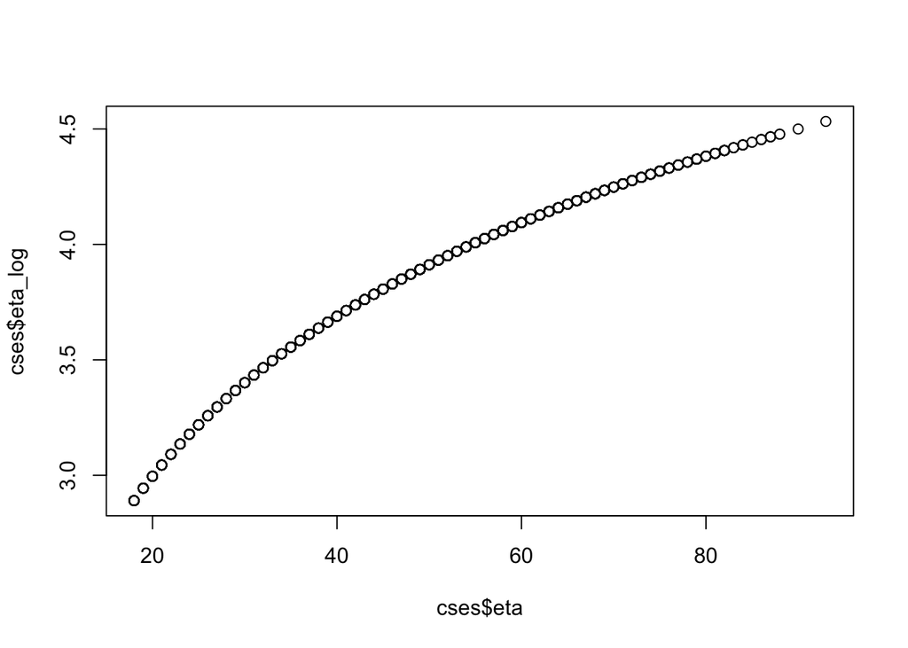

```r
plot(cses$eta, cses$eta_log)
```

- **Centratura**: operazione che si fa talvolta con le variabili metriche da includere come variabili indipendenti nei modelli di regressione. In questo caso, centriamo la variabile sulla **mediana**:

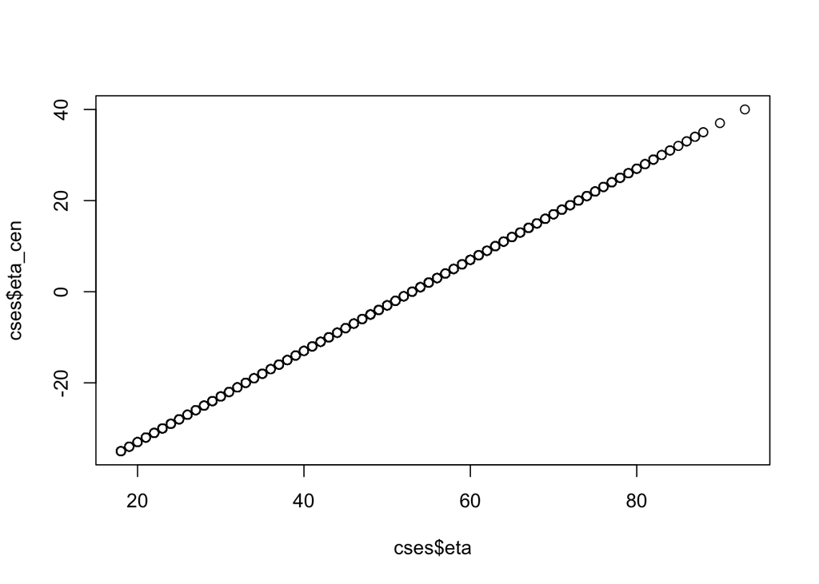

```r
cses$eta_cen <- cses$eta - median(cses$eta, na.rm = T)
plot(cses$eta, cses$eta_cen)
```

- **Standardizzazione**: operazione simile alla centratura, secondo me ancora più utile. Per standardizzare una variabile la centriamo sulla **media**, e cambiamo la scala dividendola per la sua **deviazione standard**:

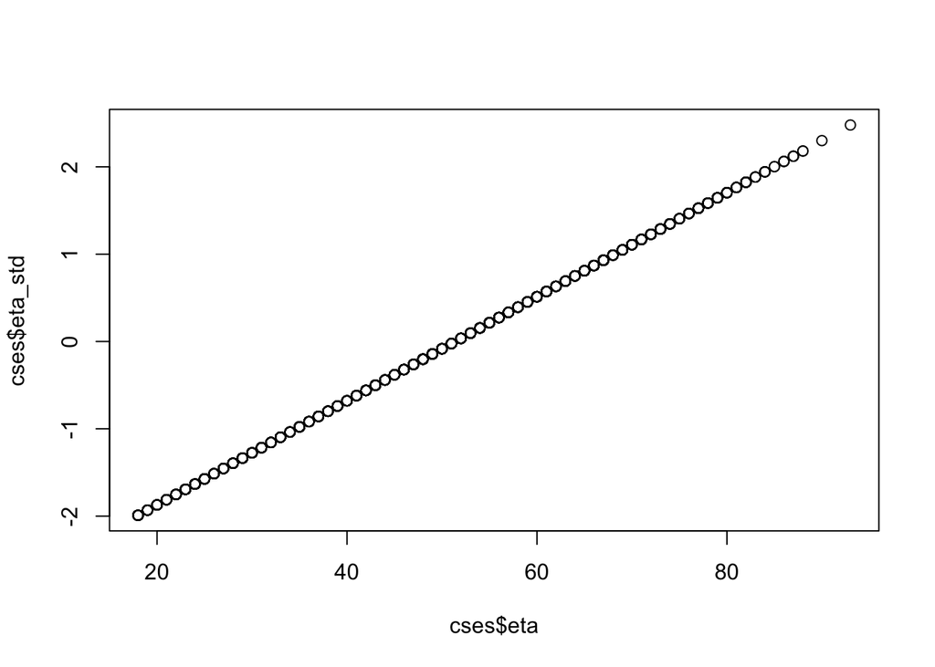

```r
cses$eta_std <- (cses$eta - mean(cses$eta, na.rm = T)) / sd(cses$eta, na.rm = T)
plot(cses$eta, cses$eta_std)
```

- La funzione `scale()` esegue queste trasformazioni in automatico:

```r
# Centratura (sulla media)
head(
  cbind(
    cses$eta - mean(cses$eta, na.rm = T),
    scale(cses$eta, center = T, scale = F)
  )
)
```

```
##           [,1]      [,2]
## [1,]  8.598201  8.598201
## [2,] 10.598201 10.598201
## [3,] 16.598201 16.598201
## [4,] 10.598201 10.598201
## [5,]  2.598201  2.598201
## [6,] 19.598201 19.598201
```

```r
# Standardizzazione
head(
  cbind(
    (cses$eta - mean(cses$eta, na.rm = T)) / sd(cses$eta, na.rm = T),
    scale(cses$eta, center = T, scale = T)
  )
)
```

```
##           [,1]      [,2]
## [1,] 0.5124959 0.5124959
## [2,] 0.6317059 0.6317059
## [3,] 0.9893360 0.9893360
## [4,] 0.6317059 0.6317059
## [5,] 0.1548658 0.1548658
## [6,] 1.1681511 1.1681511
```

- Un’altro tipo di operazione che si svolge talvolta con le variabili metriche è cambiare la scala in modo che vada da $0$ a $1$:

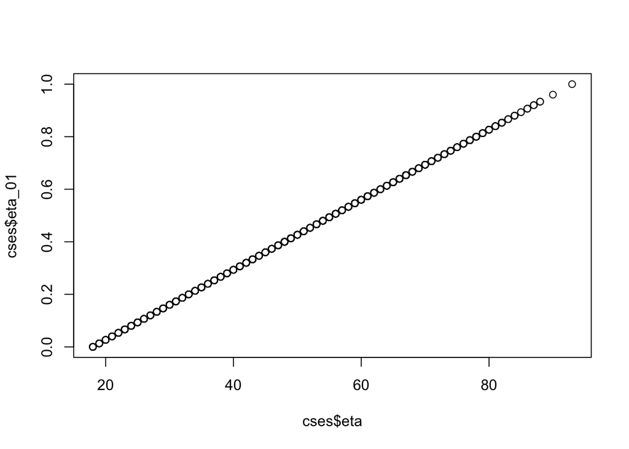

```r
cses$eta_01 <- (cses$eta - min(cses$eta, na.rm = T)) / (max(cses$eta, na.rm = T) - min(cses$eta, na.rm = T))
plot(cses$eta, cses$eta_01)
```

## Variabili categoriche

Nelle variabili categoriche i valori numerici sono semplici etichette di categorie, non hanno alcun valore quantitativo (al massimo possono dirci qualcosa sull’ordine delle categorie, come nelle variabili ordinali).

Un esempio è la variabile `eco_eval`: questa variabile ha valori numerici [`-1`, `0`, `1`], ma non si riferiscono a una reale quantità. I valori potrebbero anche essere `10`, `11` e `12`, e l’ordine rimarrebbe immutato. In altre parole, i valori si riferiscono a **categorie**, ovvero **etichette** che identificano **gruppi** di osservazioni (come la categoria “Italiano” identifica un gruppo di persone sulla base della loro nazionalità). Quello che si può fare con i gruppi è:

1. Cambiare le etichette per modificare l’ordine delle categorie
2. Mettere alcune categorie assieme per avere gruppi più grandi

Per esempio, la variabile `area` ha 4 categorie

```r
table(cses$area)
```

```
##
##     Centro   Nord-Est Nord-Ovest        Sud
##        446        349        553        653
```

Vogliamo mettere assieme gli intervistati che vivono nel Nord-Est con quelli che vivono nel Nord-Ovest nella categoria “Nord”. Il modo per farlo è con la funzione `ifelse()`:

```r
cses$area_2 <- ifelse(cses$area == "Nord-Est" | cses$area == "Nord-Ovest", "Nord", cses$area)
table(cses$area, cses$area_2)
```

```
##
##              Centro Nord Sud
##   Centro        446    0   0
##   Nord-Est        0  349   0
##   Nord-Ovest      0  553   0
##   Sud             0    0 653
```

```r
cses$area_3 <- ifelse(cses$area %in% c("Nord-Est", "Nord-Ovest"), "Nord", cses$area)
table(cses$area, cses$area_3)
```

```
##
##              Centro Nord Sud
##   Centro        446    0   0
##   Nord-Est        0  349   0
##   Nord-Ovest      0  553   0
##   Sud             0    0 653
```

La funzione `ifelse()` si usa praticamente in tutti questi casi. Può venire anche utilizzata per operazioni multiple. Per esempio, vogliamo creare una variabile in cui raggruppiamo gli intervistati per fasce di età (come con `eta_gr`, ma con gruppi differenti):

```r
cses$eta_gr_2 <- ifelse(cses$eta <= 30, "<=30",
                        ifelse(cses$eta <= 50, "31-50",
                               "51+"))
with(cses, table(eta, eta_gr_2))
```

```
##     eta_gr_2
## eta  <=30 31-50 51+
##   18   15     0   0
##   19   14     0   0
##   20   15     0   0
##   21   21     0   0
##   22   19     0   0
##   23   30     0   0
##   24   27     0   0
##   25   23     0   0
##   26   27     0   0
##   27   32     0   0
##   28   27     0   0
##   29   33     0   0
##   30   21     0   0
```

[output cut: 60 more lines]

La funzione `cut()` aiuta a sistematicizzare un po’ questo processo, per evitare di avere troppi `ifelse()` contenuti uno dentro l’altro:

```r
cses$eta_gr_3 <- cut(cses$eta,
    breaks = c(-Inf, 25, 35, 45, 55, 65, +Inf),
    labels = c("<=24", "25-34", "35-44", "45-54", "55-64", "65<"),
    right = F)
with(cses, table(eta, eta_gr_3))
```

```
##     eta_gr_3
## eta  <=24 25-34 35-44 45-54 55-64 65<
##   18   15     0     0     0     0   0
##   19   14     0     0     0     0   0
##   20   15     0     0     0     0   0
##   21   21     0     0     0     0   0
##   22   19     0     0     0     0   0
##   23   30     0     0     0     0   0
##   24   27     0     0     0     0   0
##   25    0    23     0     0     0   0
##   26    0    27     0     0     0   0
##   27    0    32     0     0     0   0
##   28    0    27     0     0     0   0
##   29    0    33     0     0     0   0
##   30    0    21     0     0     0   0
```

[output cut: 60 more lines]

Tuttavia, questa funzione ha dei problemi di chiarezza che fanno sí che spesso si preferisca usare in ogni caso tanti `ifelse()`.

# Eliminare le variabili

Ovviamente quando si creano troppe variabili è anche possibile eliminarne alcune. Questo si può fare con le parentesi quadre e con l’operatore `%in%`:

```r
to.drop <- c("newvar", "area_2", "area_3", "eta_log", "eta_cen", "eta_std", "eta_01", "eta_gr_2", "eta_gr_3")
cses <- cses[, !names(cses) %in% to.drop]
```

# Aggiungere osservazioni o variabili da altri dataset

A volte nelle nostre operazioni di data management capita di dover mettere assieme dati da diverse fonti. Una matrice è un oggetto quadrato con righe e colonne e quindi, intuitivamente, si possono aggiungere righe (osservazioni) o colonne (variabili).

## Aggiungere osservazioni

Ricordate i due dataset `cses_sud` e `cses_centro` che abbiamo creato poco fa? Immaginiamo che non siano due parti di un unico dataset ma che siano effettivamente due dataset separati, magari raccolti in diverse parti di Italia (questo capita più facilmente con dati raccolti in paesi diversi). Come facciamo ad aggiungere le osservazioni degli intervistati in Centro Italia a quelle degli intervistati del Sud? Utilizziamo la funzione `rbind()` che conosciamo già:

```r
cses_cs <- rbind(cses_sud, cses_centro)
table(cses_cs$area)
```

```
##
## Centro    Sud
##    446    653
```

Notare tuttavia che aggiungere osservazioni non è un’operazione che si fa troppo spesso. Innanzi tutto perchè può essere fatto solo se i due dataset da cui provengono le osservazioni hanno esattamente le stesse variabili chiamate con gli stessi nomi. Molto più comune è aggiungere variabili.

## Aggiungere variabili

Aggiungere variabili a un dataset è complicato, perchè i valori devono essere assegnati alle giuste osservazioni. Perchè questo sia fattibile occorre quindi che entrambi i dataset abbiano almeno una variabile in comune che identifica in modo univoco le singole osservazioni e che possa fare da **ponte** tra loro. Se non abbiamo questa variabile, non possiamo fare niente. Se invece la abbiamo, possiamo mettere assieme i due dataset utilizzando la funzione `merge()`.

PEr fare un esempio, carichiamo il file “*cses2018edu.dta*”, che include una variabile chiamata `titstu` che registra il titolo di studio dell’intervistato.

```r
cses_edu <- import("cses2018edu.dta")
head(cses_edu)
```

```
##   id titstu
## 1  1      9
## 2  2      5
## 3  3      5
## 4  4      6
## 5  5      5
## 6  6      4
```

Notare che il data frame `cses_edu` ha 2 variabili: `id` (il codice identificativo dell’intervistato che abbiamo anche in `cses`) e `titstu`. Mentre la seconda è l’informazione che effettivamente vogliamo aggiungere ai nostri dati, la prima è necessaria per assegnare i valori di titolo di studio alle osservazioni giuste.

```r
cses_full <- merge(cses, cses_edu, by = "id")
head(cses_full)
```

```
##   id     sex eta eta_gr           mip1           mip2 eco_eval       area titstu
## 1  1 Femmina  60    55+      la scuola      il lavoro       -1        Sud      9
## 2  2 Maschio  62    55+           <NA>           <NA>       -1     Centro      5
## 3  3 Femmina  68    55+ poverta,lavoro   immigrazione       -1   Nord-Est      5
## 4  4 Maschio  62    55+      il lavoro   immigrazione       -1        Sud      6
## 5  5 Femmina  54  35 54         lavoro   immigrazione       -1 Nord-Ovest      5
## 6  6 Femmina  71    55+      il lavoro l'immigrazione        0 Nord-Ovest      4
```

# Esercizio

In `cses` abbiamo la variabile `eco_eval`, definita sopra come *la valutazione di come lo stato dell’economia del paese è cambiato nel corso dell’anno precedente, codificato in 3 classi (1 = è migliorato; 0 = è rimasto uguale; -1 = è peggiorato)*.

Calcolate la media di questa variabile per gli intervistati nelle diverse aree geografiche (Nord-Est, Nord-Ovest, Centro, Sud). Come interpretate le differenze osservate?